# Análisis de Datos

Saul Ortiz-Santacruz

15-12-2025

# 1 Introducción

El presente estudio analiza información proveniente de la Encuesta de Actividad Económica (EAE) del Instituto Nacional de Estadística y Censos (INEC) de Ecuador, con el propósito de caracterizar el comportamiento de variables económicas clave reportadas por las unidades productivas del país. La EAE constituye una fuente oficial y consolidada para comprender la dinámica empresarial, abarcando aspectos como ventas, comercio exterior, personal ocupado y otras dimensiones relevantes para el análisis económico.

El objetivo general de este trabajo es ofrecer una visión clara y estructurada del conjunto de datos, identificando patrones, distribuciones y relaciones existentes entre las variables seleccionadas. En particular, se busca:

Describir la estructura de la base de datos, destacando sus componentes principales y el tipo de información que contiene.

Examinar patrones relevantes, derivados de la exploración inicial de las variables más representativas.

Estimar estadísticas descriptivas que permitan comprender la variabilidad y el comportamiento general de los indicadores analizados.

Este análisis proporciona una primera aproximación al comportamiento económico de las unidades incluidas en la EAE y sienta las bases para estudios posteriores que profundicen en tendencias sectoriales, relaciones causales o modelos predictivos.

# 2 Datos

El análisis se basa en la información proveniente de la Encuesta de Actividad Económica (EAE) del Instituto Nacional de Estadística y Censos (INEC), la cual recopila datos detallados sobre el desempeño económico de establecimientos productivos en Ecuador. La base utilizada incluye variables relacionadas con ventas, comercio exterior, personal ocupado y otras características empresariales que permiten describir y modelar el comportamiento económico del sector.

En primer lugar, se realizó una caracterización básica del conjunto de datos, identificando el número de registros, tipos de variables y presencia de valores faltantes. A partir de esta estructura inicial se generaron medidas estadísticas descriptivas —como medias, medianas, desviaciones estándar, rangos y percentiles— para comprender el comportamiento general de las variables más relevantes.

Además del análisis descriptivo, se desarrolló un estudio exploratorio más profundo, orientado a identificar estructuras subyacentes y relaciones complejas dentro del conjunto de datos. Para ello se aplicaron técnicas multivariantes como:

Modelos basados en árboles, específicamente Random Forest, utilizados para analizar la importancia de las variables y estimar patrones predictivos en función de los indicadores económicos seleccionados.

Estas técnicas complementan el análisis inicial y permiten obtener una visión integral del comportamiento de los datos, combinando descripción estadística, visualización y métodos avanzados de modelamiento.

## 2.1 Datos usados

Para este estudio se empleó la base de datos proveniente de la Encuesta de Actividad Económica (EAE) del Instituto Nacional de Estadística y Censos (INEC) de Ecuador. El archivo original, suministrado en formato SPSS (.sav), contiene información detallada sobre las actividades económicas de establecimientos formales del país, incluyendo variables relacionadas con ventas, personal ocupado, comercio exterior y otros indicadores productivos.

```r
library(haven)
library(dplyr)

base <- read_sav("SAMPLE_MIL.sav")
```

```r
library(knitr)

tabla_20 <- data.frame(
  Variable = names(base)[1:20]
)

kable(
  tabla_20,
  caption = "Primeras 20 variables de la base de datos",
  align = "l"
)
```

Primeras 20 variables de la base de datos

| Variable |
| --- |
| id_empresa |
| anio |
| situacion |
| forma_institucional |
| unidad_legal_tipo |
| clase_contribuyente |
| obligado_llevar_contabilidad |
| gsectores |
| codigo_seccion |
| codigo_division |
| codigo_clase |
| zona_planif |
| codigo_provincia |
| codigo_canton |
| ventas_totales |
| ventas_nacionales |
| exportaciones_netas |
| ventas_rimpe |
| ventas_totales_rimpe |
| importaciones |

# 3 Análisis Exploratorio

El análisis exploratorio se enfocó en comprender el comportamiento general de la información contenida en la base de datos de la Encuesta de Actividad Económica (EAE). Para ello, se seleccionaron algunas variables representativas —como ventas totales, importaciones, exportaciones y plazas equivalentes de empleo— con el fin de ilustrar los patrones principales presentes en el conjunto de datos.

## 3.1 Descriptivos basicos de las variables mas relevantes

```r
library(dplyr)

# vector con los nombres REALES de tus variables en la base
vars_relev <- c(
  "ventas_totales",
  "importaciones",
  "exportaciones",
  "plazas_equiv",
  "plazas_equiv_hombres",
  "plazas_equiv_mujeres"
)

# crear subconjunto de datos relevantes
datos_relev <- base %>% select(all_of(vars_relev))
```

Tabla 1. Resumen estadístico de las variables seleccionadas

| Variable | Min | Q1.25. | Median | Mean | Q3.75. | Max | NAs |
| --- | --- | --- | --- | --- | --- | --- | --- |
| ventas_totales | 0.00 | 0.00 | 0.00 | 610119.90 | 0.00 | 92788666.00 | 150 |
| importaciones | 16.36 | 2709.18 | 16234.29 | 2323187.69 | 247975.07 | 66598418.26 | 952 |
| exportaciones | 100.00 | 30275.00 | 118750.00 | 1740492.86 | 1594700.00 | 15627100.00 | 986 |
| plazas_equiv | 0.08 | 1.00 | 1.08 | 15.59 | 3.08 | 4225.58 | 335 |
| plazas_equiv_hombres | 0.08 | 1.00 | 1.00 | 13.35 | 3.00 | 2393.92 | 540 |
| plazas_equiv_mujeres | 0.08 | 1.00 | 1.00 | 8.93 | 2.00 | 1831.67 | 527 |

## 3.2 GRAFICOS DESCRIPTIVOS

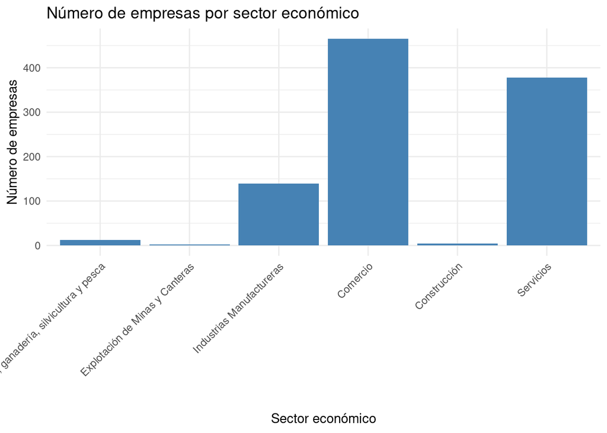

```r
library(ggplot2)
library(dplyr)

ggplot(base, aes(x = as_factor(gsectores))) +
  geom_bar(fill = "steelblue") +
  labs(
    title = "Número de empresas por sector económico",
    x = "Sector económico",
    y = "Número de empresas"
  ) +
  theme_minimal() +
  theme(axis.text.x = element_text(angle = 45, hjust = 1))
```

La Figura muestra la predominancia de ciertos que sectores puede estar asociada a factores como la dinámica del mercado interno, las barreras de entrada, la especialización productiva y las condiciones regulatorias. Estos resultados constituyen un insumo relevante para el análisis posterior, ya que permiten contextualizar las diferencias observadas en variables económicas y laborales, como ventas, empleo y productividad, entre los distintos sectores económicos.

A manera demostrativa se presenta un historama de frecuencias en función de la variable ventas totales, se aclara la necesidad de un ajuste en escalas, dada las diferencias entre valores extremos.

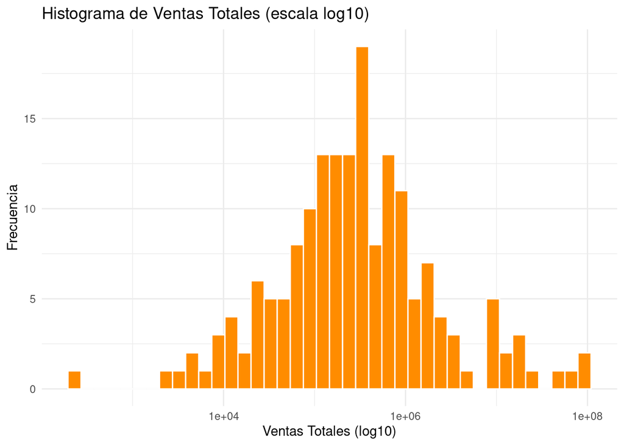

```r
base_log <- base %>%
  filter(!is.na(ventas_totales),
         ventas_totales > 0)

# Graficar en escala logarítmica
g2 <- ggplot(base_log, aes(x = ventas_totales)) +
  geom_histogram(bins = 40, fill = "darkorange", color = "white") +
  scale_x_log10() +
  labs(
    title = "Histograma de Ventas Totales (escala log10)",
    x = "Ventas Totales (log10)",
    y = "Frecuencia"
  ) +
  theme_minimal()

# Mostrar gráfico 2
print(g2)
```

El objetivo de este apartado es caracterizar la estructura interna de los datos antes de aplicar métodos más avanzados.

# 4 Análisis Estadístico y Modelos

En esta sección se aplicarán técnicas estadísticas o modelos analíticos según la naturaleza del problema, tales como:

- Asociacion A partir de la base original se extrajo una tabla reducida para el análisis de asociación, compuesta por 850 registros y dos variables: el sector económico (gsectores) y las ventas totales (ventas_totales), excluyendo observaciones con valores faltantes.

Para esto:

```r
library(dplyr)

datos_asoc <- base %>%
  select(gsectores, ventas_totales) %>%
  filter(!is.na(gsectores), !is.na(ventas_totales))
```

```r
dim(datos_asoc)
```

```
## [1] 850   2
```

```r
names(datos_asoc)
```

```
## [1] "gsectores"      "ventas_totales"
```

```r
library(knitr)

kable(
  head(datos_asoc, 6),
  caption = "Vista preliminar del conjunto de datos reducido para el análisis de asociación (sector–ventas)"
)
```

Vista preliminar del conjunto de datos reducido para el análisis de asociación (sector–ventas)

| gsectores | ventas_totales |
| --- | --- |
| 6 | 0 |
| 4 | 113831 |
| 4 | 0 |
| 4 | 0 |
| 6 | 0 |
| 6 | 0 |

Ahora realizaremos un analisis de asociación. para esto convertimos la variable a alta media y baja.

```r
library(dplyr)

# Asegurar que gsectores sea categórica (aunque esté codificada con números)
datos_asoc$gsectores <- as.factor(datos_asoc$gsectores)

# Mediana solo de ventas positivas (para evitar que muchos ceros dañen el corte)
med_pos <- median(datos_asoc$ventas_totales[datos_asoc$ventas_totales > 0], na.rm = TRUE)

# Crear 3 categorías robustas
datos_asoc <- datos_asoc %>%
  mutate(
    nivel_ventas3 = case_when(
      ventas_totales == 0 ~ "Bajas",
      ventas_totales > 0 & ventas_totales <= med_pos ~ "Medias",
      ventas_totales > med_pos ~ "Altas",
      TRUE ~ NA_character_
    )
  )

# Asegurar orden de niveles
datos_asoc$nivel_ventas3 <- factor(datos_asoc$nivel_ventas3, levels = c("Bajas", "Medias", "Altas"))
```

Con el fin de analizar los patrones de asociación entre el sector económico y el nivel de ventas, se construyó una tabla de contingencia a partir del conjunto de datos reducido previamente definido. Para ello, las ventas totales fueron clasificadas en tres categorías —bajas, medias y altas— y se cruzaron con la variable sectorial (gsectores). Esta representación permite identificar la distribución conjunta de las empresas según su actividad económica y su desempeño en ventas, constituyendo la base para el análisis exploratorio de asociaciones sectoriales.

```r
library(knitr)

# Tabla de contingencia
tabla_asociacion <- table(datos_asoc$gsectores, datos_asoc$nivel_ventas3)

# Convertir a data.frame y hacer visible el sector como columna
tabla_df <- as.data.frame.matrix(tabla_asociacion)
tabla_df <- cbind(Sector = rownames(tabla_df), tabla_df)
rownames(tabla_df) <- NULL

# Mostrar en el documento final
kable(
  tabla_df,
  caption = "Tabla X. Tabla de contingencia entre sector económico (gsectores) y nivel de ventas"
)
```

| Sector | Bajas | Medias | Altas |
| --- | --- | --- | --- |
| 1 | 2 | 3 | 5 |
| 2 | 0 | 0 | 2 |
| 3 | 99 | 9 | 7 |
| 4 | 343 | 30 | 43 |
| 5 | 2 | 1 | 0 |
| 6 | 230 | 44 | 30 |

Con el fin de explorar visualmente la relación entre el sector económico y el nivel de ventas de las empresas, se presenta un gráfico de barras apiladas que muestra la distribución proporcional de las categorías de ventas (bajas, medias y altas) en cada sector. Esta representación permite identificar de manera preliminar diferencias en el comportamiento de las ventas entre sectores económicos.

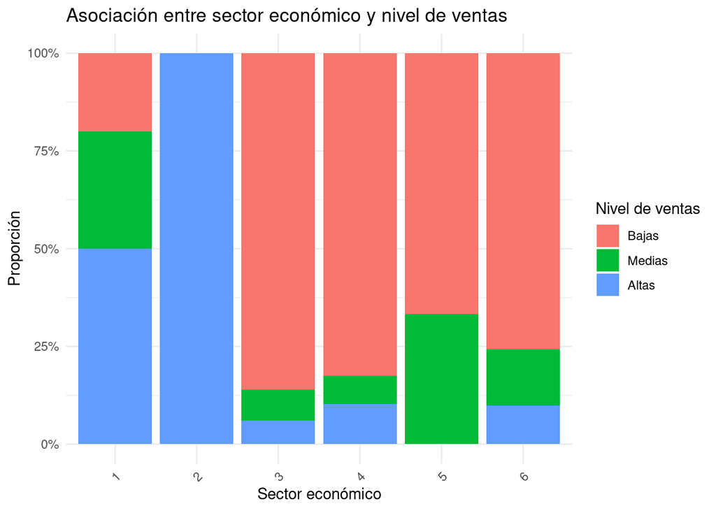

```r
library(ggplot2)
library(dplyr)
library(haven)

ggplot(datos_asoc, aes(x = as_factor(gsectores), fill = nivel_ventas3)) +
  geom_bar(position = "fill") +
  labs(
    title = "Asociación entre sector económico y nivel de ventas",
    x = "Sector económico",
    y = "Proporción",
    fill = "Nivel de ventas"
  ) +
  scale_y_continuous(labels = scales::percent_format()) +
  theme_minimal() +
  theme(axis.text.x = element_text(angle = 45, hjust = 1))
```

La Figura muestra la distribución proporcional de los niveles de ventas (bajas, medias y altas) por sector económico. Se observan diferencias claras entre sectores en la composición de los niveles de ventas. Mientras que algunos sectores concentran una alta proporción de empresas con ventas bajas, otros presentan una participación relativamente mayor de ventas medias o altas. Estas variaciones en la estructura interna de los sectores sugieren la existencia de patrones de asociación entre la actividad económica y el nivel de ventas de las empresas.

- Pruebas estadísticas

```r
# Prueba Chi-cuadrado de independencia
chi_sector_ventas <- chisq.test(tabla_asociacion)

chi_sector_ventas
```

```
##
##  Pearson's Chi-squared test
##
## data:  tabla_asociacion
## X-squared = 56.518, df = 10, p-value = 1.642e-08
```

Para evaluar formalmente la relación entre el sector económico y el nivel de ventas, se aplicó la prueba de Chi-cuadrado de independencia sobre la tabla de contingencia sector–ventas. Los resultados muestran un estadístico χ² = 56.518 con 10 grados de libertad y un valor p = 1.642 × 10⁻⁸, lo que indica una asociación estadísticamente significativa entre ambas variables. Este hallazgo confirma que la distribución de los niveles de ventas difiere según el sector económico, respaldando los patrones identificados en el análisis gráfico.

## 4.1 RANDOM FOREST

Con el fin de profundizar en el análisis estadístico y explorar relaciones no lineales entre las variables económicas, se evaluó la aplicación de modelos de aprendizaje automático. Considerando la naturaleza mixta de los datos (variables numéricas y categóricas), así como la necesidad de interpretabilidad de los resultados, se seleccionó el algoritmo Random Forest como técnica principal de análisis avanzado. Este método permite identificar la importancia relativa de las variables explicativas y ofrece una alta robustez frente a la presencia de valores atípicos y distribuciones asimétricas, características comunes en datos económicos empresariales.

Paso 1. Preparación de los datos. En esta etapa se seleccionó la variable objetivo (ventas totales) junto con un conjunto de variables explicativas de carácter económico, sectorial y geográfico. Las variables categóricas fueron transformadas a formato factor y se eliminaron los registros con valores faltantes, con el fin de obtener un conjunto de datos consistente y adecuado para el entrenamiento del modelo Random Forest.

```r
library(dplyr)

# 1) Selección de variable objetivo y predictoras
datos_rf <- base %>%
  select(
    ventas_totales,          # Variable objetivo (Y)
    anio,
    gsectores,
    codigo_seccion,
    codigo_division,
    codigo_clase,
    zona_planif,
    codigo_provincia,
    codigo_canton,
    importaciones,
    exportaciones_netas
  )

# 2) Conversión de variables categóricas a factor
datos_rf <- datos_rf %>%
  mutate(across(
    c(gsectores, codigo_seccion, codigo_division, codigo_clase,
      zona_planif, codigo_provincia, codigo_canton),
    as.factor
  ))

# 3) Eliminación de filas con valores faltantes
datos_rf <- na.omit(datos_rf)

# 4) Verificación básica del dataset final
dim(datos_rf)
```

```
## [1] 46 11
```

Paso 2. División de los datos. El conjunto de datos preparado fue dividido aleatoriamente en dos subconjuntos: uno de entrenamiento (70% de los registros), utilizado para ajustar el modelo, y otro de prueba (30%), destinado a evaluar su desempeño predictivo sobre datos no observados.

```r
set.seed(123)  # Para reproducibilidad

# Número total de observaciones
n <- nrow(datos_rf)

# Índices para el conjunto de entrenamiento (70%)
indices_train <- sample(1:n, size = 0.7 * n)

# Conjuntos de datos
train <- datos_rf[indices_train, ]
test  <- datos_rf[-indices_train, ]

# Verificación de tamaños
dim(train)
```

```
## [1] 32 11
```

```r
dim(test)
```

```
## [1] 14 11
```

PASO 3: Entrenamiento del modelo Random Forest

```r
library(dplyr)

# Crear train_rf y test_rf desde train y test
train_rf <- train %>%
  select(
    ventas_totales,
    anio,
    gsectores,
    codigo_seccion,
    codigo_division,
    zona_planif,
    codigo_provincia,
    importaciones,
    exportaciones_netas
  ) %>%
  mutate(across(
    c(gsectores, codigo_seccion, codigo_division, zona_planif, codigo_provincia),
    as.factor
  ))

test_rf <- test %>%
  select(
    ventas_totales,
    anio,
    gsectores,
    codigo_seccion,
    codigo_division,
    zona_planif,
    codigo_provincia,
    importaciones,
    exportaciones_netas
  ) %>%
  mutate(across(
    c(gsectores, codigo_seccion, codigo_division, zona_planif, codigo_provincia),
    as.factor
  ))
```

```r
library(randomForest)

# Detectar factores con más de 53 niveles
niv <- sapply(train_rf, function(x) if (is.factor(x)) nlevels(x) else 0)
cols_quitar <- names(niv[niv > 53])

# Crear versiones depuradas de train/test
train_rf2 <- train_rf %>% select(-all_of(cols_quitar))
test_rf2  <- test_rf  %>% select(-all_of(cols_quitar))

set.seed(123)
modelo_rf <- randomForest(
  ventas_totales ~ .,
  data = train_rf2,
  ntree = 500,
  importance = TRUE
)

# Mostrar qué columnas se quitaron y el resumen del modelo
cols_quitar
```

```
## [1] "codigo_division"
```

```r
modelo_rf
```

```
##
## Call:
##  randomForest(formula = ventas_totales ~ ., data = train_rf2,      ntree = 500, importance = TRUE)
##                Type of random forest: regression
##                      Number of trees: 500
## No. of variables tried at each split: 2
##
##           Mean of squared residuals: 3.407465e+14
##                     % Var explained: 13.12
```

```r
library(knitr)

# Predicciones sobre el conjunto de prueba
pred_test <- predict(modelo_rf, newdata = test_rf2)

# Valores reales
real <- test_rf2$ventas_totales

# Métricas de error
MAE  <- mean(abs(pred_test - real))
RMSE <- sqrt(mean((pred_test - real)^2))

# Tabla comparativa (primeros 10 casos)
tabla_comp <- data.frame(
  Real = real,
  Predicho = pred_test,
  Error = pred_test - real
)

kable(
  head(tabla_comp, 10),
  digits = 2,
  caption = "Comparación Real vs Predicho (primeros 10 registros del conjunto de prueba)"
)
```

Comparación Real vs Predicho (primeros 10 registros del conjunto de prueba)

| Real | Predicho | Error |
| --- | --- | --- |
| 0 | 4551518.5 | 4551518.5 |
| 0 | 4553336.1 | 4553336.1 |
| 1199122 | 5450889.3 | 4251767.3 |
| 385481 | 2343283.9 | 1957802.9 |
| 0 | 2338908.0 | 2338908.0 |
| 222625 | 1907227.4 | 1684602.4 |
| 0 | 710871.2 | 710871.2 |
| 0 | 20303119.8 | 20303119.8 |
| 789373 | 4631671.1 | 3842298.1 |
| 723874 | 859773.1 | 135899.1 |

Paso 5. Importancia de variables. Con el fin de identificar los factores que influyen en las ventas totales, se analizó la importancia relativa de las variables predictoras a partir del modelo Random Forest entrenado. Esta medida permite evaluar la contribución de cada variable en la reducción del error de predicción y facilita la interpretación económica de los resultados.

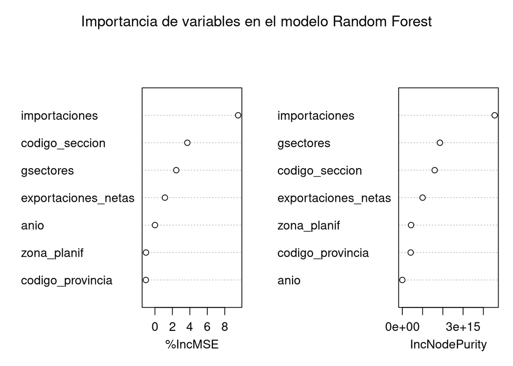

Importancia de las variables según el modelo Random Forest (%IncMSE)

|  | Variable | IncMSE |
| --- | --- | --- |
| importaciones | importaciones | 9.54 |
| codigo_seccion | codigo_seccion | 3.71 |
| gsectores | gsectores | 2.44 |
| exportaciones_netas | exportaciones_netas | 1.14 |
| anio | anio | 0.00 |
| zona_planif | zona_planif | -1.03 |
| codigo_provincia | codigo_provincia | -1.05 |

```r
varImpPlot(
  modelo_rf,
  main = "Importancia de variables en el modelo Random Forest"
)
```

El análisis de importancia de variables basado en Random Forest muestra que las importaciones constituyen el principal factor explicativo de las ventas totales, seguido de la clasificación sectorial de las empresas. Las variables asociadas al comercio exterior presentan una influencia positiva, mientras que las variables geográficas y administrativas exhiben un aporte marginal o negativo, sugiriendo que su capacidad explicativa es limitada en comparación con los factores económicos directos.

# 5 Conclusiones

Finalmente, se sintetizan los aspectos más importantes encontrados en el análisis:

Alta heterogeneidad y asimetría del tejido empresarial El análisis descriptivo evidencia una estructura empresarial altamente heterogénea, caracterizada por una fuerte asimetría en las variables económicas, especialmente en las ventas totales. La mayoría de las empresas opera a pequeña escala, mientras que un número reducido concentra valores elevados, confirmando la presencia de micro y pequeñas empresas junto con outliers significativos.

Diferenciación sectorial en el desempeño económico La distribución por sectores económicos y el análisis de asociación sector–nivel de ventas muestran que los sectores no presentan comportamientos homogéneos. Existen diferencias claras en la escala productiva y comercial, lo que refleja una especialización sectorial con impactos directos en ventas y estructura empresarial.